# Palmer Penguins Modeling

Import the Palmer Penguins dataset and print out the first few rows.

Suppose we want to predict `bill_depth_mm` using the other variables in the dataset.

**Dummify** all variables that require this.

```python
# Code Here
!pip install palmerpenguins
import numpy as np
import pandas as pd
from palmerpenguins import load_penguins
from plotnine import ggplot, aes, geom_point, geom_bar,scale_y_continuous, geom_line
from sklearn.linear_model import LinearRegression
from sklearn.pipeline import Pipeline
from sklearn.model_selection import train_test_split
from sklearn.compose import ColumnTransformer
from sklearn.preprocessing import OneHotEncoder
from sklearn.preprocessing import PolynomialFeatures
from sklearn.metrics import r2_score
import numpy as np
from sklearn.metrics import mean_squared_error
```

```python
myData = load_penguins()
myData.head()

myData = myData.dropna()

x = myData.drop(['bill_depth_mm'], axis=1)
y = myData['bill_depth_mm']

x_train, x_test, y_train, y_test = train_test_split(x,y,test_size=0.25)
x_train
```

|  | species | island | bill_length_mm | flipper_length_mm | body_mass_g | sex | year |
| --- | --- | --- | --- | --- | --- | --- | --- |
| 327 | Chinstrap | Dream | 51.4 | 201.0 | 3950.0 | male | 2009 |
| 16 | Adelie | Torgersen | 38.7 | 195.0 | 3450.0 | female | 2007 |
| 246 | Gentoo | Biscoe | 44.5 | 214.0 | 4850.0 | female | 2009 |
| 94 | Adelie | Dream | 36.2 | 187.0 | 3300.0 | female | 2008 |
| 29 | Adelie | Biscoe | 40.5 | 180.0 | 3950.0 | male | 2007 |
| ... | ... | ... | ... | ... | ... | ... | ... |
| 259 | Gentoo | Biscoe | 53.4 | 219.0 | 5500.0 | male | 2009 |
| 276 | Chinstrap | Dream | 46.5 | 192.0 | 3500.0 | female | 2007 |
| 60 | Adelie | Biscoe | 35.7 | 185.0 | 3150.0 | female | 2008 |
| 61 | Adelie | Biscoe | 41.3 | 195.0 | 4400.0 | male | 2008 |
| 325 | Chinstrap | Dream | 49.8 | 198.0 | 3675.0 | female | 2009 |

249 rows × 7 columns

```python
lr = LinearRegression()
enc = OneHotEncoder()

ct = ColumnTransformer(
    [("dummify_s", enc, ['species']),
    ("dummify_i", enc, ['island']),
    ("dummify_sex", enc, ['sex'])]
)



my_pipeline = Pipeline(
    [('dummify_everything', ct), ('ols', lr)]
)
```

```python
fitted_pipeline = my_pipeline.fit(x_train,y_train)
fitted_pipeline
```

```
Pipeline(steps=[('dummify_everything',
                 ColumnTransformer(transformers=[('dummify_s', OneHotEncoder(),
                                                  ['species']),
                                                 ('dummify_i', OneHotEncoder(),
                                                  ['island']),
                                                 ('dummify_sex',
                                                  OneHotEncoder(), ['sex'])])),
                ('ols', LinearRegression())])
```

```python
y_preds = fitted_pipeline.predict(x_test)
```

Let’s use the other variables to predict `bill_depth_mm`. Prepare your data and fit the following models on a training dataset subset of the entire dataset:

- Four different models, each containing a different set of predictor variables

Create a plot like the right plot of Fig 1. in our `Model Validation` chapter with the training and test error plotted for each of your four models.

Which of your models was best?

```python
# Code Here
# Firsrt Model:

myData = load_penguins()
myData.head()

myData = myData.dropna()

x = myData[['bill_length_mm']]
y = myData['bill_depth_mm']


x_train, x_test, y_train, y_test = train_test_split(x,y,test_size=0.25)
x_train


lr = LinearRegression()

my_pipeline = Pipeline(
    [('ols', lr)]
)


fitted_pipeline = my_pipeline.fit(x_train,y_train)
fitted_pipeline


y_preds_1 = fitted_pipeline.predict(x_test)
y_train_1 = fitted_pipeline.predict(x_train)
```

```python
# Second Model

myData = load_penguins()
myData.head()

myData = myData.dropna()

x = myData.drop(['bill_depth_mm', 'year'], axis=1)
y = myData['bill_depth_mm']

x_train, x_test, y_train, y_test = train_test_split(x,y,test_size=0.25)
x_train


lr = LinearRegression()
enc = OneHotEncoder()

ct = ColumnTransformer(
    [("dummify_s", enc, ['species']),
    ("dummify_i", enc, ['island']),
    ("dummify_sex", enc, ['sex'])]
)


my_pipeline = Pipeline(
    [('dummify_everything', ct), ('ols', lr)]
)


fitted_pipeline = my_pipeline.fit(x_train,y_train)
fitted_pipeline

y_preds_2 = fitted_pipeline.predict(x_test)
y_train_2 = fitted_pipeline.predict(x_train)
```

```python
myData = load_penguins()
myData.head()

myData = myData.dropna()

x = myData.drop(['bill_depth_mm', 'year','species','flipper_length_mm'], axis=1)
y = myData['bill_depth_mm']

x_train, x_test, y_train, y_test = train_test_split(x,y,test_size=0.25)
x_train


lr = LinearRegression()
enc = OneHotEncoder()

ct = ColumnTransformer(
    [
    ("dummify_i", enc, ['island']),
    ("dummify_sex", enc, ['sex'])]
)


my_pipeline = Pipeline(
    [('dummify_everything', ct), ('ols', lr)]
)


fitted_pipeline = my_pipeline.fit(x_train,y_train)
fitted_pipeline

y_preds_3 = fitted_pipeline.predict(x_test)
y_train_3 = fitted_pipeline.predict(x_train)
```

```python
myData = load_penguins()
myData.head()

myData = myData.dropna()

x = myData.drop(['bill_depth_mm', 'year','species','island','body_mass_g'], axis=1)
y = myData['bill_depth_mm']

x_train, x_test, y_train, y_test = train_test_split(x,y,test_size=0.25)
x_train


lr = LinearRegression()
enc = OneHotEncoder()

ct = ColumnTransformer(
    [
    ("dummify_sex", enc, ['sex'])]
)


my_pipeline = Pipeline(
    [('dummify_everything', ct), ('ols', lr)]
)


fitted_pipeline = my_pipeline.fit(x_train,y_train)
fitted_pipeline

y_preds_4 = fitted_pipeline.predict(x_test)
y_train_4 = fitted_pipeline.predict(x_train)
```

```python
mse1 = mean_squared_error(y_test, y_preds_1)
mse2 = mean_squared_error(y_test, y_preds_2)
mse3 = mean_squared_error(y_test, y_preds_3)
mse4 = mean_squared_error(y_test, y_preds_4)


msetrain1 = mean_squared_error(y_train, y_train_1)
msetrain2 = mean_squared_error(y_train, y_train_2)
msetrain3 = mean_squared_error(y_train, y_train_3)
msetrain4 = mean_squared_error(y_train, y_train_4)
```

```python
from pandas.core.frame import DataFrame

df = pd.DataFrame(columns=['mse', 'group', 'predictor'])

df['mse'] = [mse1, mse2, mse3, mse4, msetrain1, msetrain2, msetrain3, msetrain4]

df['group'] = ['test', 'test', 'test', 'test', 'train', 'train', 'train', 'train']

df['predictor'] = [1, 5, 3, 2, 1, 5, 3, 2]
df
```

|  | mse | group | predictor |
| --- | --- | --- | --- |
| 0 | 4.037774 | test | 1 |
| 1 | 8.464691 | test | 5 |
| 2 | 5.740941 | test | 3 |
| 3 | 3.135823 | test | 2 |
| 4 | 4.362852 | train | 1 |
| 5 | 7.288185 | train | 5 |
| 6 | 5.767956 | train | 3 |
| 7 | 3.396116 | train | 2 |

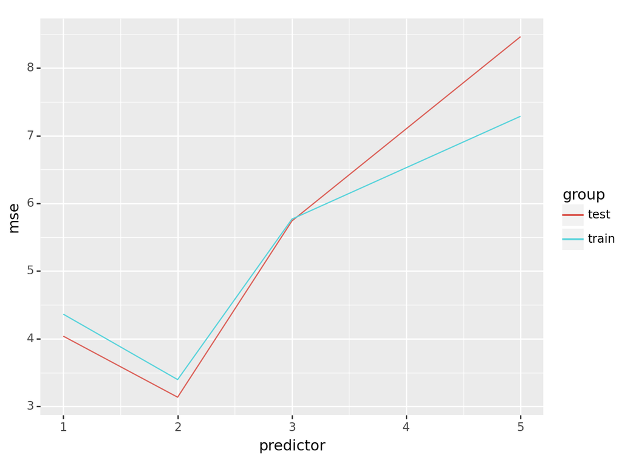

```
<Figure Size: (640 x 480)>
```

```python
plot = ggplot(df, aes(x = 'predictor', y = 'mse', color = 'group'))
plot += geom_line()
plot
```